# Problem Sets: 2 & 3

Braulio Güémez

31/8/2021

# *Problem Set 02*

## Open the libraries and the data

```r
library(dplyr)
library(ggplot2)
library(readr)

nc <- read_csv("https://docs.google.com/spreadsheets/d/e/2PACX-1vTm2WZwNBoQdZhMgot7urbtu8eG7tzAq-60ZJsQ_nupykCAcW0OXebVpHksPWyR4x8xJTVQ8KAulAFS/pub?gid=202410847&single=true&output=csv")
```

## Exercise 1

R is considering `habit`to be a character type of variable. `Visits` is considered as a number with decimals type of variable.

## Exercise 2

There is a positive relation between the length of a pregnancy and the birth weight of a baby in pounds. Thus, for every week increase there is a correspondent increase in the weight of the baby.

## Exercise 3

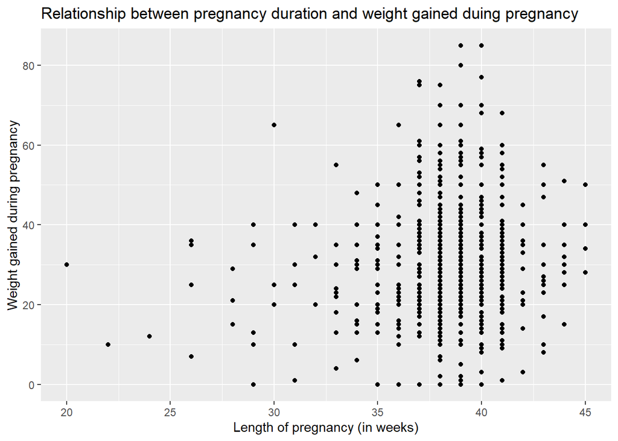

```r
nc |> ggplot(aes(weeks, gained)) + geom_point() + labs(x="Length of pregnancy (in weeks)", y="Weight gained during pregnancy", title="Relationship between pregnancy duration and weight gained duing pregnancy")
```

## Exercise 4

A. It colors the points according to the values of the variable `premie`, that indicates whether a birth was early (`premie`) or went full term.

B. Three

C. 36 weeks

## Exercise 5

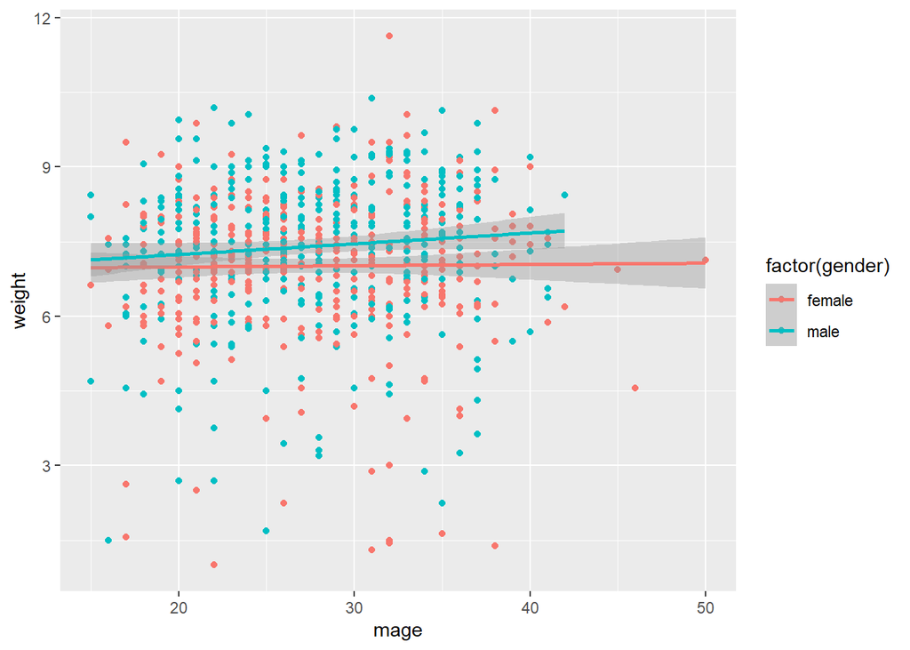

```r
nc |> ggplot(aes(mage,weight, col=factor(gender))) + geom_point() + geom_smooth(method="lm")
```

There seems to be no strong relationship between the mother’s age and the weight of her newborn. There is a slight positive slope (blue line) in the case of male newborns but not in the case of female ones.

## Exercise 6

A. The number of births of a single child.

B. 39

C. 1 bin and all the 800 cases would be in that bin

## Exercise 7

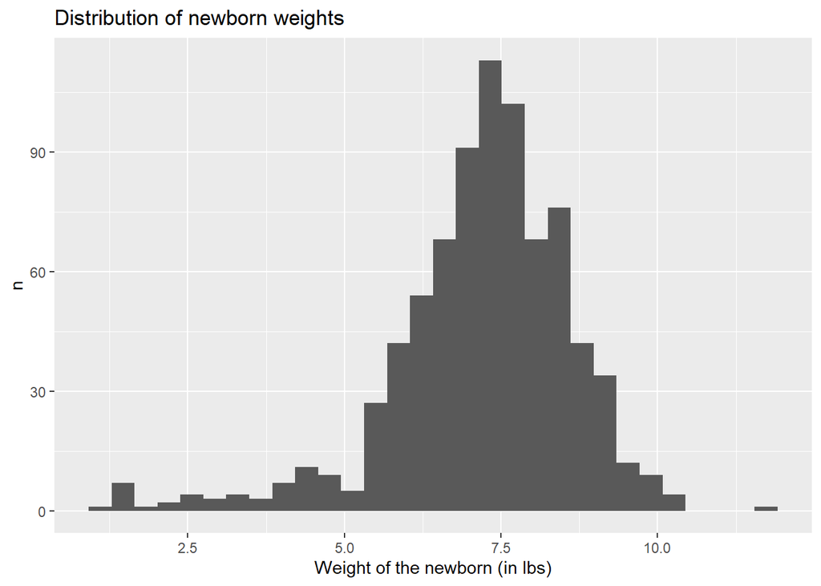

```r
nc |> ggplot(aes(weight)) + geom_histogram() + labs(x="Weight of the newborn (in lbs)", y="n" , title="Distribution of newborn weights")
```

## Exercise 8

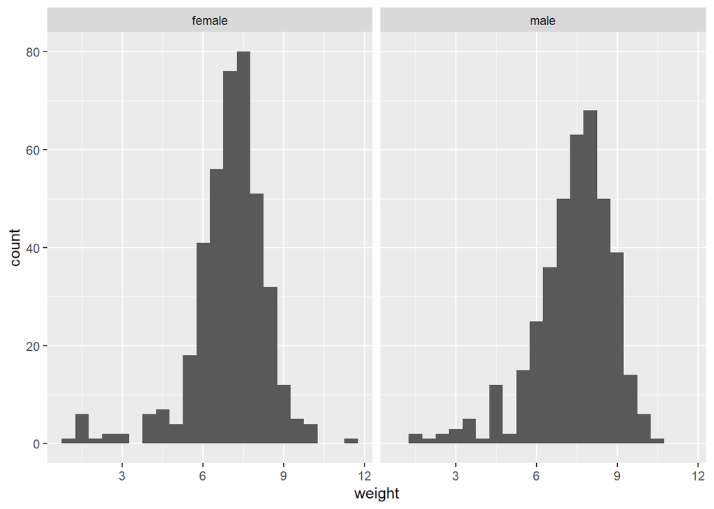

```r
nc |> ggplot(aes(weight)) + geom_histogram(binwidth  =0.5) + facet_wrap(.~gender)
```

## Exercise 9

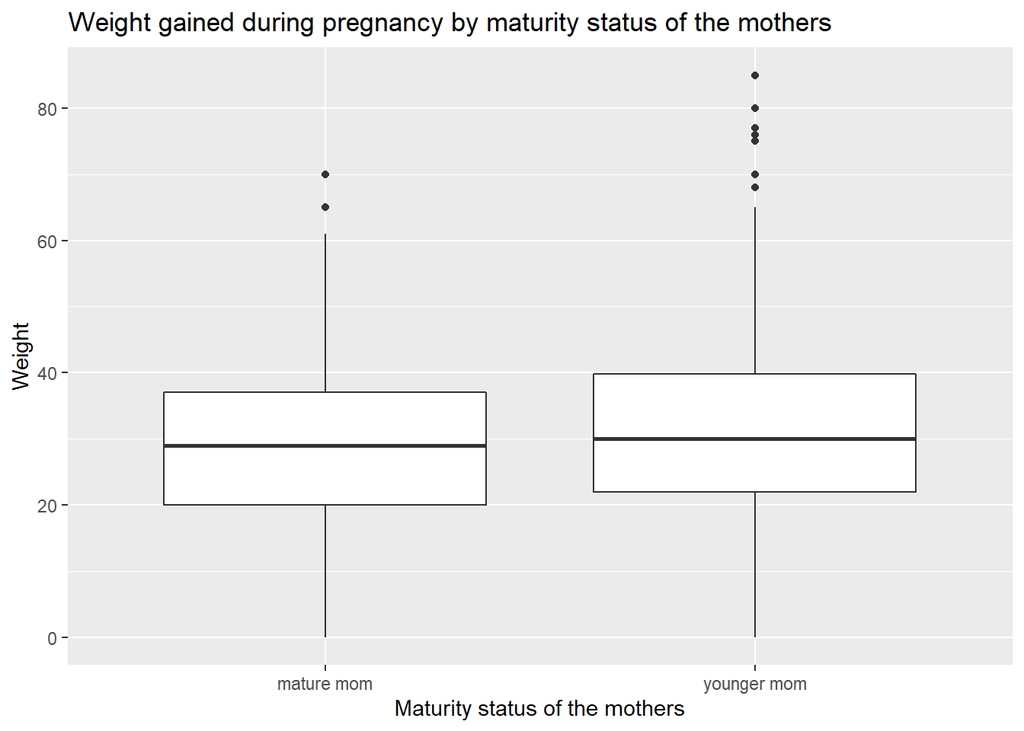

```r
nc |>  ggplot(aes(mature, gained)) + geom_boxplot() + labs(x="Maturity status of the mothers", y="Weight", title="Weight gained during pregnancy by maturity status of the mothers")
```

The median weight gain during pregnancy is a bit larger in younger moms than older moms

## Exercise 10

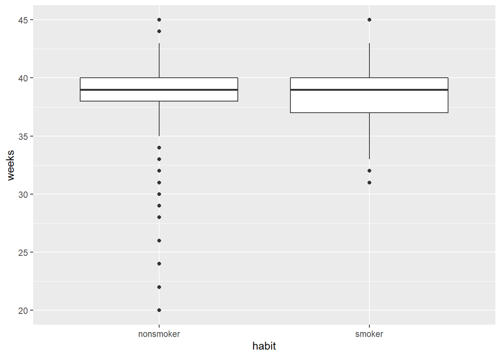

```r
nc |>  ggplot(aes(habit, weeks)) + geom_boxplot()
```

## Exercise 11

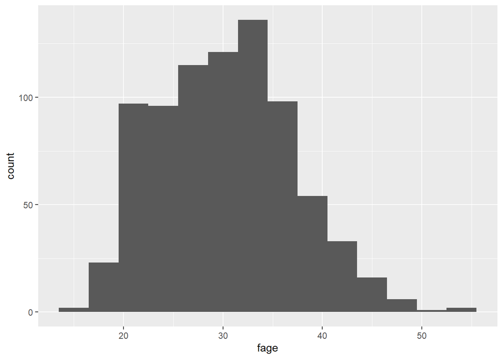

```r
nc |>  ggplot(aes(fage)) + geom_histogram(binwidth = 3)
```

## Exercise 12

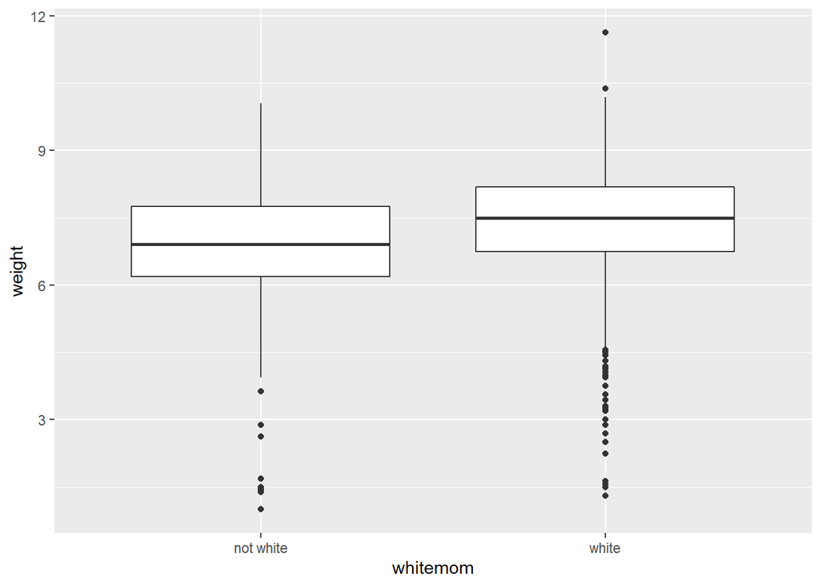

```r
nc |>  ggplot(aes(whitemom, weight)) + geom_boxplot()
```

The median birth weight of babies is higher for white than non-white mothers.

## Exercise 13

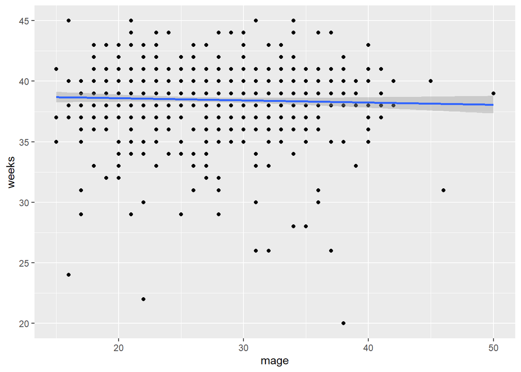

```r
nc |>  ggplot(aes(mage, weeks)) + geom_point() + geom_smooth(method="lm")
```

There seems to be no significant association between the mother’s age and the duration of pregnancy

# *Problem Set 03*

## Open the data (libraries already opened)

```r
data(txhousing)
glimpse(txhousing)
```

```
## Rows: 8,602
## Columns: 9
## $ city      <chr> "Abilene", "Abilene", "Abilene", "Abilene", "Abilene", "Abil~
## $ year      <int> 2000, 2000, 2000, 2000, 2000, 2000, 2000, 2000, 2000, 2000, ~
## $ month     <int> 1, 2, 3, 4, 5, 6, 7, 8, 9, 10, 11, 12, 1, 2, 3, 4, 5, 6, 7, ~
## $ sales     <dbl> 72, 98, 130, 98, 141, 156, 152, 131, 104, 101, 100, 92, 75, ~
## $ volume    <dbl> 5380000, 6505000, 9285000, 9730000, 10590000, 13910000, 1263~
## $ median    <dbl> 71400, 58700, 58100, 68600, 67300, 66900, 73500, 75000, 6450~
## $ listings  <dbl> 701, 746, 784, 785, 794, 780, 742, 765, 771, 764, 721, 658, ~
## $ inventory <dbl> 6.3, 6.6, 6.8, 6.9, 6.8, 6.6, 6.2, 6.4, 6.5, 6.6, 6.2, 5.7, ~
## $ date      <dbl> 2000.000, 2000.083, 2000.167, 2000.250, 2000.333, 2000.417, ~
```

## Question 1

The last city listed in the data set (in row 8602) Wichita Falls

## Question 2

The `listings` variable display the total active listings

## Question 3

```r
txhousing <- txhousing |> select(-inventory)

glimpse(txhousing)
```

```
## Rows: 8,602
## Columns: 8
## $ city     <chr> "Abilene", "Abilene", "Abilene", "Abilene", "Abilene", "Abile~
## $ year     <int> 2000, 2000, 2000, 2000, 2000, 2000, 2000, 2000, 2000, 2000, 2~
## $ month    <int> 1, 2, 3, 4, 5, 6, 7, 8, 9, 10, 11, 12, 1, 2, 3, 4, 5, 6, 7, 8~
## $ sales    <dbl> 72, 98, 130, 98, 141, 156, 152, 131, 104, 101, 100, 92, 75, 1~
## $ volume   <dbl> 5380000, 6505000, 9285000, 9730000, 10590000, 13910000, 12635~
## $ median   <dbl> 71400, 58700, 58100, 68600, 67300, 66900, 73500, 75000, 64500~
## $ listings <dbl> 701, 746, 784, 785, 794, 780, 742, 765, 771, 764, 721, 658, 7~
## $ date     <dbl> 2000.000, 2000.083, 2000.167, 2000.250, 2000.333, 2000.417, 2~
```

## Question 4

```r
dallas_sub <- txhousing |> filter(city=="Dallas", (year==2012 | year==2013))

dallas_sub
```

```
## # A tibble: 24 x 8
##    city    year month sales     volume median listings  date
##    <chr>  <int> <int> <dbl>      <dbl>  <dbl>    <dbl> <dbl>
##  1 Dallas  2012     1  2555  509458081 150800    16721 2012
##  2 Dallas  2012     2  3085  634067291 157100    17173 2012.
##  3 Dallas  2012     3  4068  898320563 167300    17433 2012.
##  4 Dallas  2012     4  4291  983333297 168700    17632 2012.
##  5 Dallas  2012     5  5004 1175419749 175100    17726 2012.
##  6 Dallas  2012     6  5196 1209024869 177900    17587 2012.
##  7 Dallas  2012     7  4859 1117428758 176000    17314 2012.
##  8 Dallas  2012     8  5264 1168296112 174200    16611 2013.
##  9 Dallas  2012     9  4151  921678400 173500    15994 2013.
## 10 Dallas  2012    10  4214  885330428 166700    15008 2013.
## # ... with 14 more rows
```

## Question 5

```r
dallas_sub <- dallas_sub |> mutate(prct_sold=sales/listings*100)

dallas_sub$prct_sold
```

```
##  [1] 15.28019 17.96425 23.33505 24.33643 28.22972 29.54455 28.06399 31.68984
##  [9] 25.95348 28.07836 27.86166 30.95047 25.80906 28.98232 41.15438 44.60264
## [17] 48.17364 44.83844 46.19657 45.34103 37.58844 36.08580 33.32493 39.99620
```

## Question 6

```r
dallas_summary <- dallas_sub |> group_by(month) |> summarize(mean_per=mean(prct_sold))

dallas_summary
```

```
## # A tibble: 12 x 2
##    month mean_per
##    <int>    <dbl>
##  1     1     20.5
##  2     2     23.5
##  3     3     32.2
##  4     4     34.5
##  5     5     38.2
##  6     6     37.2
##  7     7     37.1
##  8     8     38.5
##  9     9     31.8
## 10    10     32.1
## 11    11     30.6
## 12    12     35.5
```

## Question 7

```r
  dallas_summary  |> arrange(desc(mean_per))
```

```
## # A tibble: 12 x 2
##    month mean_per
##    <int>    <dbl>
##  1     8     38.5
##  2     5     38.2
##  3     6     37.2
##  4     7     37.1
##  5    12     35.5
##  6     4     34.5
##  7     3     32.2
##  8    10     32.1
##  9     9     31.8
## 10    11     30.6
## 11     2     23.5
## 12     1     20.5
```

## Question 8

The code summarizes all of the steps followed in previous questions: calculate and sort the average percentage of listings that were sold in Dallas from 2012 to 2013

## Question 9

```r
txhousing |> filter(month==1, year==2015) |> select(city, listings) |> arrange(listings)
```

```
## # A tibble: 46 x 2
##    city            listings
##    <chr>              <dbl>
##  1 San Marcos            85
##  2 Garland              198
##  3 Irving               278
##  4 Victoria             280
##  5 Nacogdoches          284
##  6 Paris                299
##  7 Brazoria County      301
##  8 Odessa               308
##  9 Texarkana            317
## 10 Lufkin               404
## # ... with 36 more rows
```

San Marcos was the city in January of 2015 that had the fewest houses listed.

## Question 10

```r
txhousing |> filter(year==2012) |> group_by(month) |> summarize (summ_sales = sum(sales) ) |>
 arrange(desc(summ_sales))
```

```
## # A tibble: 12 x 2
##    month summ_sales
##    <int>      <dbl>
##  1     8      29995
##  2     6      29574
##  3     5      28348
##  4     7      28269
##  5    10      24259
##  6     4      23954
##  7     9      23256
##  8     3      22934
##  9    12      22457
## 10    11      22018
## 11     2      17689
## 12     1      14299
```

In August

## Question 11

```r
austin_sub <- txhousing |> filter((city=="Austin" | city =="Dallas"), (year==2000 | year==2001)) |> select(sales, city) |> group_by(city) |> summarize(total_sold=sum(sales))

austin_sub
```

```
## # A tibble: 2 x 2
##   city   total_sold
##   <chr>       <dbl>
## 1 Austin      37013
## 2 Dallas      92438
```